# Introduction to *Bioconductor*

Juan R Gonzalez juanr.gonzalez@isglobal.org (part of this material is based on Martin Morgan’s courses)

January, 2017

# 1 Project Overview

## 1.1 About

[Bioconductor](https://bioconductor.org): Analysis and comprehension of high-throughput genomic data

- Statistical analysis: large data, technological artifacts, designed experiments; rigorous
- Comprehension: biological context, visualization, reproducibility
- High-throughput
  - Sequencing: RNASeq, ChIPSeq, variants, copy number, …
  - Microarrays: expression, SNP, …
  - Flow cytometry, proteomics, images, …

Packages, vignettes, work flows

- 1296 software packages; also…
  - ‘Annotation’ packages – static data bases of identifier maps, gene models, pathways, etc; e.g., TxDb.Hsapiens.UCSC.hg19.knownGene
  - ’Experiment packages – data sets used to illustrate software functionality, e.g., airway
- Discover and navigate via [biocViews](https://bioconductor.org/packages/)
- Package ‘landing page’
  - Title, author / maintainer, short description, citation, installation instructions, …, download statistics
- All user-visible functions have help pages, most with runnable examples
- ‘Vignettes’ an important feature in Bioconductor – narrative documents illustrating how to use the package, with integrated code
- ‘Release’ (every six months) and ‘devel’ branches
- [Support site](https://support.bioconductor.org); [videos](https://www.youtube.com/user/bioconductor), [recent courses](https://bioconductor.org/help/course-materials/)

Package installation and use

- A package needs to be installed once, using the instructions on the package landing page (e.g., DESeq2).

  ```r
  source("https://bioconductor.org/biocLite.R")
  biocLite(c("DESeq2", "org.Hs.eg.db"))
  ```

- `biocLite()` installs *Bioconductor*, [CRAN](https://cran.r-project.org), and github packages.
- Once installed, the package can be loaded into an R session

  ```r
  library(GenomicRanges)
  ```

  and the help system queried interactively, as outlined above:

  ```r
  help(package="GenomicRanges")
  vignette(package="GenomicRanges")
  vignette(package="GenomicRanges", "GenomicRangesHOWTOs")
  ?GRanges
  ```

## 1.2 Key concepts

Goals

- Reproducibility
- Interoperability
- Use

What a few lines of *R* has to say

```r
x <- rnorm(1000)
y <- x + rnorm(1000)
df <- data.frame(X=x, Y=y)
plot(Y ~ X, df)
fit <- lm(Y ~ X, df)
anova(fit)
```

```
## Analysis of Variance Table
##
## Response: Y
##            Df Sum Sq Mean Sq F value    Pr(>F)
## X           1 985.50  985.50  1037.6 < 2.2e-16 ***
## Residuals 998 947.84    0.95
## ---
## Signif. codes:  0 '***' 0.001 '**' 0.01 '*' 0.05 '.' 0.1 ' ' 1
```

```r
abline(fit)
```

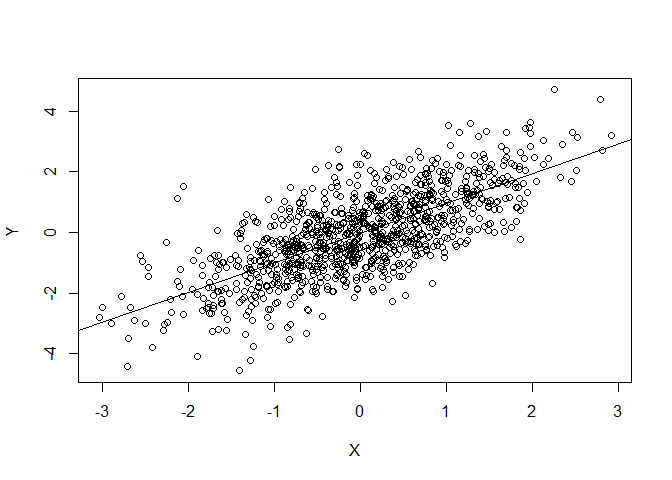

Classes and methods – “S3”

- `data.frame()`
- Defines *class* to coordinate data
- Creates an *instance* or *object*
- `plot()`, `lm()`, `anova()`, `abline()`: *methods* defined on *generics* to transform instances
- Discovery and help

  ```r
  class(fit)
  methods(class=class(fit))
  methods(plot)
  ?"plot"
  ?"plot.formula"
  ```

- tab completion!

*Bioconductor* classes and methods – “S4”

- Example: working with DNA sequences

  ```r
  library(Biostrings)
  dna <- DNAStringSet(c("AACAT", "GGCGCCT"))
  reverseComplement(dna)
  ```

  ```
  ##   A DNAStringSet instance of length 2
  ##     width seq
  ## [1]     5 ATGTT
  ## [2]     7 AGGCGCC
  ```

- Discovery and help

  ```r
  class(dna)
  ?"DNAStringSet-class"
  ?"reverseComplement,DNAStringSet-method"
  ```

## 1.3 High-throughput sequence analysis work flows

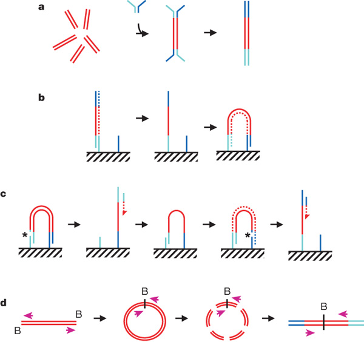

# 2 Handling Omic Data

## 2.1 SNP array data

snpStats (former [snpMatrix](http://www.bioconductor.org/packages//2.7/bioc/html/snpMatrix.html))

- FAM filele: one row per individual - identification information: Family ID, Individual ID Paternal ID, Maternal ID, Sex (1=male; 2=female; other=unknown), Phenotype.
- BIM file: one row per SNP (rs id, chromosome, position, allele 1, allele 2).
- BED file: one row per individual. Genotypes in columns.

Data are easily loaded into R by using `read.plink` function

```r
suppressMessages(library(snpStats))
snps <- read.plink("data/obesity") # there are three files obesity.fam, obesity.bim, obesity.bed
names(snps)
```

```
## [1] "genotypes" "fam"       "map"
```

Genotypes is a `snpMatrix` object

```r
geno <- snps$genotypes
geno
```

```
## A SnpMatrix with  2312 rows and  100000 columns
## Row names:  100 ... 998
## Col names:  MitoC3993T ... rs28600179
```

Annotation is a `data.frame` object

```r
annotation <- snps$map
head(annotation)
```

```
##            chromosome   snp.name cM position allele.1 allele.2
## MitoC3993T         NA MitoC3993T NA     3993        T        C
## MitoG4821A         NA MitoG4821A NA     4821        A        G
## MitoG6027A         NA MitoG6027A NA     6027        A        G
## MitoT6153C         NA MitoT6153C NA     6153        C        T
## MitoC7275T         NA MitoC7275T NA     7275        T        C
## MitoT9699C         NA MitoT9699C NA     9699        C        T
```

## 2.2 ExpressionSet

ExpressionSet

[figure not shown]

Description

- `Biobase` is part of the Bioconductor project and contains standardized data structures to represent genomic data.
- The `ExpressionSet` class is designed to combine several different sources of information into a single convenient structure.
- An `ExpressionSet` can be manipulated (e.g., subsetted, copied) conveniently, and is the input or output from many Bioconductor functions.
- The data in an `ExpressionSet` consists of expression data from microarray experiments, `meta-data’ describing samples in the experiment, annotations and meta-data about the features on the chip and information related to the protocol used for processing each sample

Print

```r
library(tweeDEseqCountData)
data(pickrell)
pickrell.eset
```

```
## ExpressionSet (storageMode: lockedEnvironment)
## assayData: 52580 features, 69 samples
##   element names: exprs
## protocolData: none
## phenoData
##   sampleNames: NA18486 NA18498 ... NA19257 (69 total)
##   varLabels: num.tech.reps population study gender
##   varMetadata: labelDescription
## featureData
##   featureNames: ENSG00000000003 ENSG00000000005 ... LRG_99 (52580 total)
##   fvarLabels: gene
##   fvarMetadata: labelDescription
## experimentData: use 'experimentData(object)'
## Annotation:
```

Get experimental data (e.g., gene expression)

```r
genes <- exprs(pickrell.eset)
genes[1:4,1:4]
```

```
##                 NA18486 NA18498 NA18499 NA18501
## ENSG00000000003       0       0       0       0
## ENSG00000000005       0       0       0       0
## ENSG00000000419      22     105      40      55
## ENSG00000000457      22     100     107      53
```

Get phenotypic data (e.g. covariates, disease status, outcomes, …)

```r
pheno <- pData(pickrell.eset)
head(pheno)
```

```
##         num.tech.reps population    study gender
## NA18486             2        YRI Pickrell   male
## NA18498             2        YRI Pickrell   male
## NA18499             2        YRI Pickrell female
## NA18501             2        YRI Pickrell   male
## NA18502             2        YRI Pickrell female
## NA18504             2        YRI Pickrell   male
```

Subsetting (everything is synchronized)

```r
eSet.male <- pickrell.eset[, pickrell.eset$gender=="male"]
eSet.male
```

```
## ExpressionSet (storageMode: lockedEnvironment)
## assayData: 52580 features, 29 samples
##   element names: exprs
## protocolData: none
## phenoData
##   sampleNames: NA18486 NA18498 ... NA19239 (29 total)
##   varLabels: num.tech.reps population study gender
##   varMetadata: labelDescription
## featureData
##   featureNames: ENSG00000000003 ENSG00000000005 ... LRG_99 (52580 total)
##   fvarLabels: gene
##   fvarMetadata: labelDescription
## experimentData: use 'experimentData(object)'
## Annotation:
```

## 2.3 Genomic ranges

GenomicRanges

- `GRanges()`: genomic coordinates to represent annotations (exons, genes, regulatory marks, …) and data (called peaks, variants, aligned reads)
- `GRangesList()`: genomic coordinates grouped into list elements (e.g., paired-end reads; exons grouped by transcript)

Operations

- intra-range: act on each range independently
  - e.g., `shift()`
- inter-range: act on all ranges in a `GRanges` object or `GRangesList` element
  - e.g., `reduce()`; `disjoin()`
- between-range: act on two separate `GRanges` or `GRangesList` objects
  - e.g., `findOverlaps()`, `nearest()`

```r
library(GenomicRanges)
gr <- GRanges("A", IRanges(c(10, 20, 22), width=5), "+")
shift(gr, 1)                            # intra-range
```

```
## GRanges object with 3 ranges and 0 metadata columns:
##       seqnames    ranges strand
##          <Rle> <IRanges>  <Rle>
##   [1]        A  [11, 15]      +
##   [2]        A  [21, 25]      +
##   [3]        A  [23, 27]      +
##   -------
##   seqinfo: 1 sequence from an unspecified genome; no seqlengths
```

```r
range(gr)                               # inter-range
```

```
## GRanges object with 1 range and 0 metadata columns:
##       seqnames    ranges strand
##          <Rle> <IRanges>  <Rle>
##   [1]        A  [10, 26]      +
##   -------
##   seqinfo: 1 sequence from an unspecified genome; no seqlengths
```

```r
reduce(gr)                              # inter-range
```

```
## GRanges object with 2 ranges and 0 metadata columns:
##       seqnames    ranges strand
##          <Rle> <IRanges>  <Rle>
##   [1]        A  [10, 14]      +
##   [2]        A  [20, 26]      +
##   -------
##   seqinfo: 1 sequence from an unspecified genome; no seqlengths
```

```r
snps <- GRanges("A", IRanges(c(11, 17, 24), width=1))
findOverlaps(snps, gr)                  # between-range
```

```
## Hits object with 3 hits and 0 metadata columns:
##       queryHits subjectHits
##       <integer>   <integer>
##   [1]         1           1
##   [2]         3           2
##   [3]         3           3
##   -------
##   queryLength: 3 / subjectLength: 3
```

```r
setdiff(range(gr), gr)                  # 'introns'
```

```
## GRanges object with 1 range and 0 metadata columns:
##       seqnames    ranges strand
##          <Rle> <IRanges>  <Rle>
##   [1]        A  [15, 19]      +
##   -------
##   seqinfo: 1 sequence from an unspecified genome; no seqlengths
```

## 2.4 Summarized experiments

SummarizedExperiment

[figure not shown]

- Coordinate feature x sample ‘assays’ with row (feature) and column (sample) descriptions.
- ‘assays’ (similar to ‘exprs’ in `ExpressionSet`objects) can be any matrix-like object, including very large on-disk representations such as HDF5Array

## 2.5 MultiDataSet

MultiDataSet

[figure not shown]

- Designed to encapsulate different types of datasets (including all classes in Bioconductor)
- It properly deals with non-complete cases situations
- Subsetting is easily performed in both: samples and features (using GenomicRanges)
- It allows to: – perform integration analysis with third party packages; – create new methods and functions for omic data integration; – encapsule new unimplemented data from any biological experiment.